# UNEP Emissions Gap Report 2026 - Chapter 2 Figures

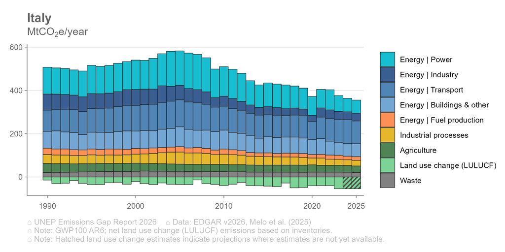

[data](https://github.com/pik-ecs/UNEP-Gap-Report-2026-Chapter-2/raw/main/results/standard/countries/UNEP-EGR-2026-country-trend.xlsx) | png | pdf | svg

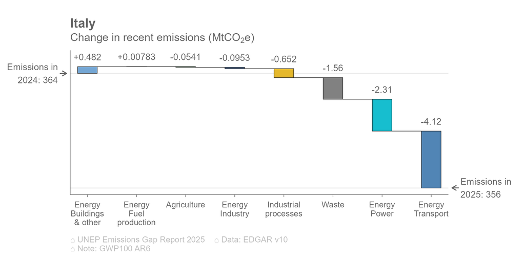

[data](https://github.com/pik-ecs/UNEP-Gap-Report-2026-Chapter-2/raw/main/results/standard/countries/UNEP-EGR-2026-country-change.xlsx) | png | pdf | svg

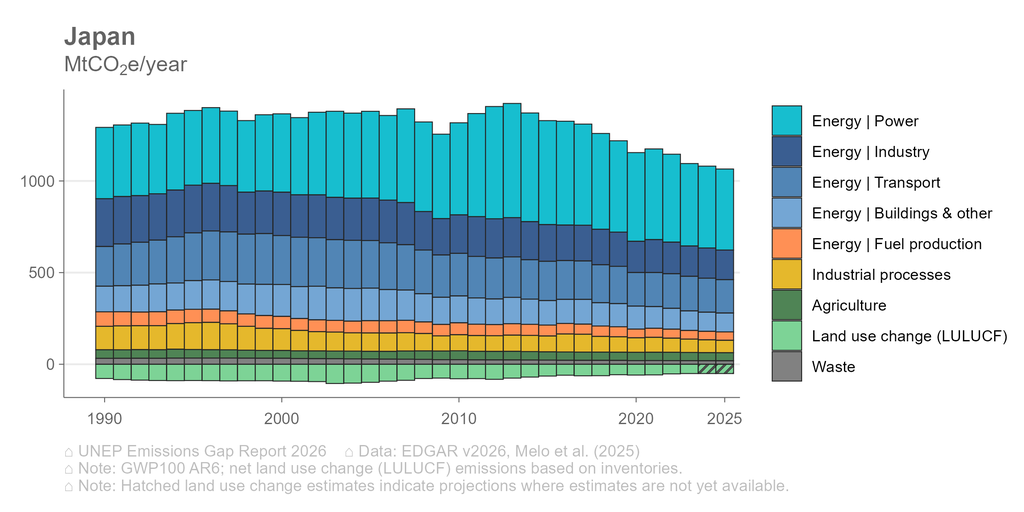

[data](https://github.com/pik-ecs/UNEP-Gap-Report-2026-Chapter-2/raw/main/results/standard/countries/UNEP-EGR-2026-country-trend.xlsx) | png | pdf | svg

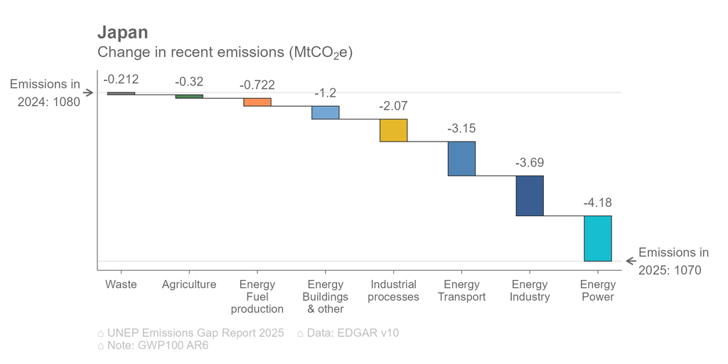

[data](https://github.com/pik-ecs/UNEP-Gap-Report-2026-Chapter-2/raw/main/results/standard/countries/UNEP-EGR-2026-country-change.xlsx) | png | pdf | svg

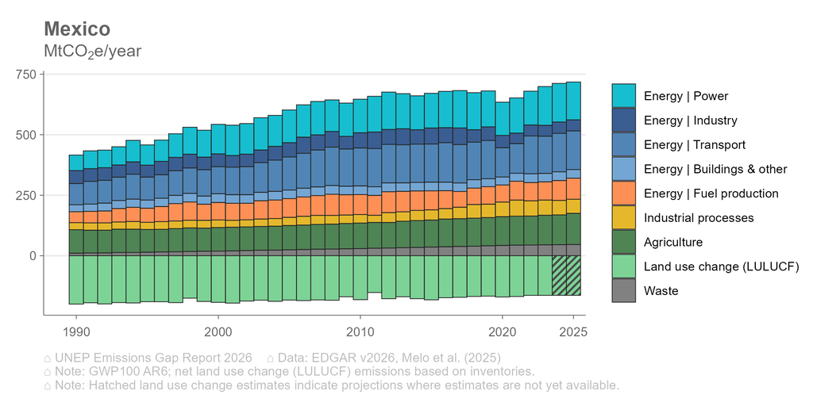

[data](https://github.com/pik-ecs/UNEP-Gap-Report-2026-Chapter-2/raw/main/results/standard/countries/UNEP-EGR-2026-country-trend.xlsx) | png | pdf | svg

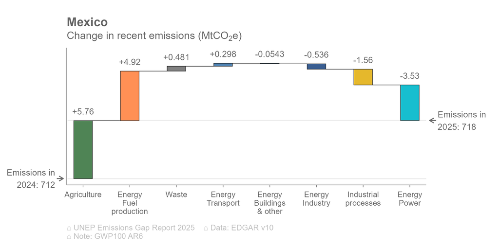

[data](https://github.com/pik-ecs/UNEP-Gap-Report-2026-Chapter-2/raw/main/results/standard/countries/UNEP-EGR-2026-country-change.xlsx) | png | pdf | svg

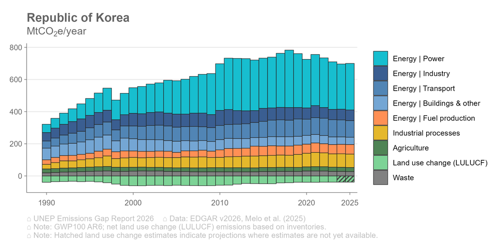

[data](https://github.com/pik-ecs/UNEP-Gap-Report-2026-Chapter-2/raw/main/results/standard/countries/UNEP-EGR-2026-country-trend.xlsx) | png | pdf | svg

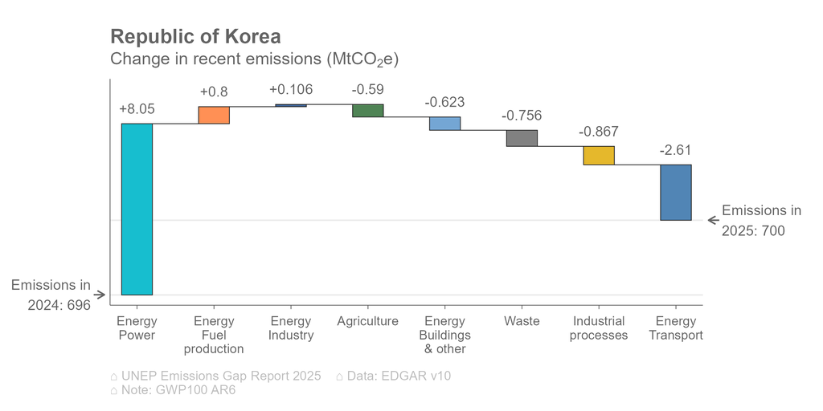

[data](https://github.com/pik-ecs/UNEP-Gap-Report-2026-Chapter-2/raw/main/results/standard/countries/UNEP-EGR-2026-country-change.xlsx) | png | pdf | svg

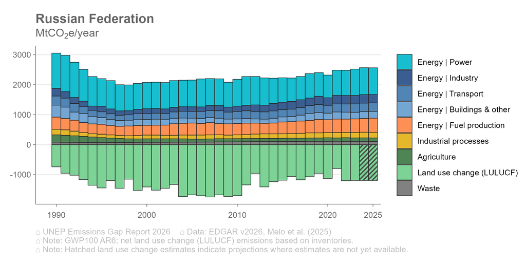

[data](https://github.com/pik-ecs/UNEP-Gap-Report-2026-Chapter-2/raw/main/results/standard/countries/UNEP-EGR-2026-country-trend.xlsx) | png | pdf | svg

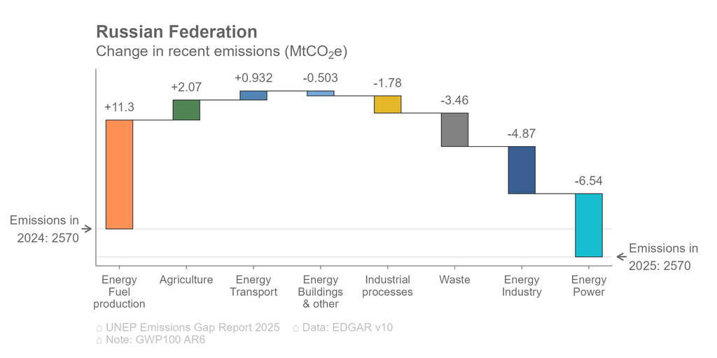

[data](https://github.com/pik-ecs/UNEP-Gap-Report-2026-Chapter-2/raw/main/results/standard/countries/UNEP-EGR-2026-country-change.xlsx) | png | pdf | svg

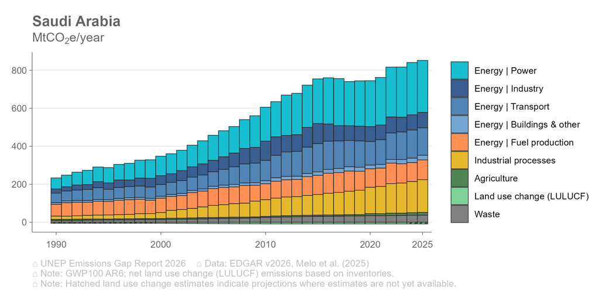

[data](https://github.com/pik-ecs/UNEP-Gap-Report-2026-Chapter-2/raw/main/results/standard/countries/UNEP-EGR-2026-country-trend.xlsx) | png | pdf | svg

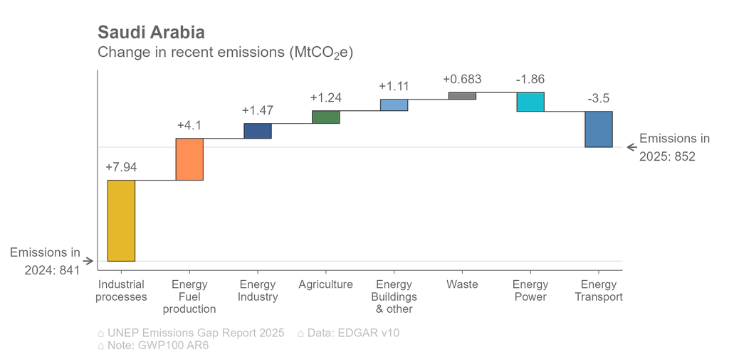

[data](https://github.com/pik-ecs/UNEP-Gap-Report-2026-Chapter-2/raw/main/results/standard/countries/UNEP-EGR-2026-country-change.xlsx) | png | pdf | svg

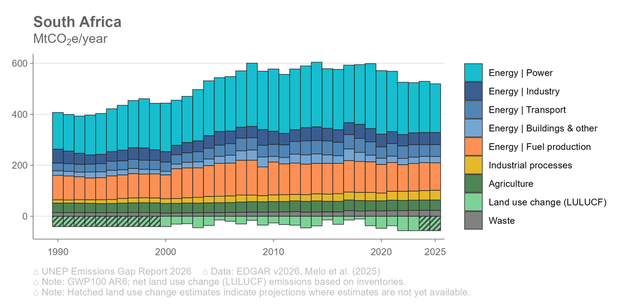

[data](https://github.com/pik-ecs/UNEP-Gap-Report-2026-Chapter-2/raw/main/results/standard/countries/UNEP-EGR-2026-country-trend.xlsx) | png | pdf | svg

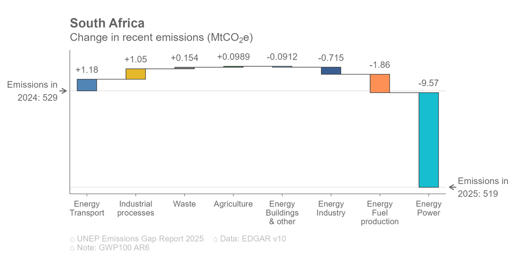

[data](https://github.com/pik-ecs/UNEP-Gap-Report-2026-Chapter-2/raw/main/results/standard/countries/UNEP-EGR-2026-country-change.xlsx) | png | pdf | svg

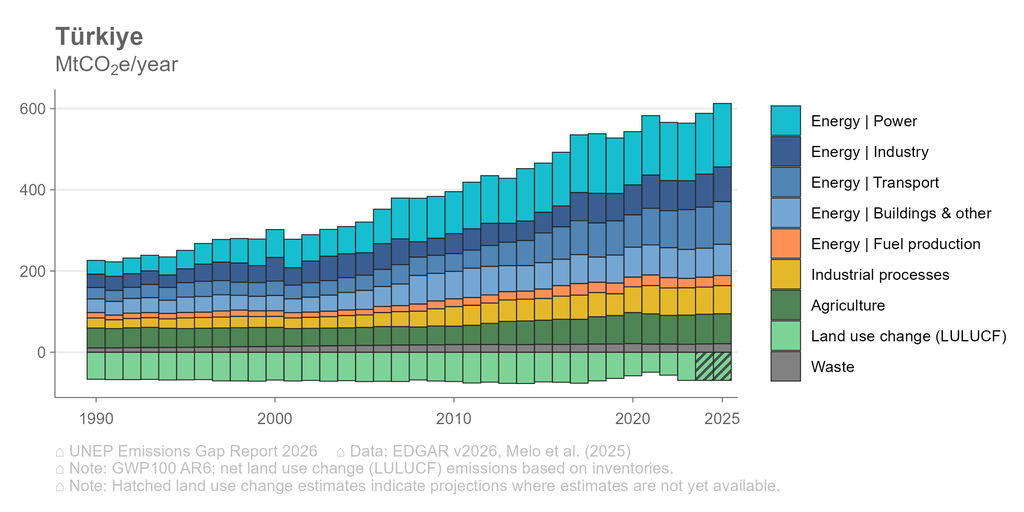

[data](https://github.com/pik-ecs/UNEP-Gap-Report-2026-Chapter-2/raw/main/results/standard/countries/UNEP-EGR-2026-country-trend.xlsx) | png | pdf | svg

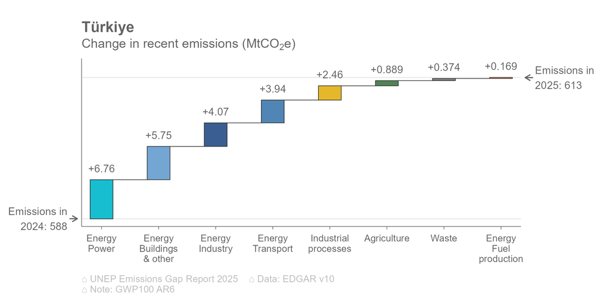

[data](https://github.com/pik-ecs/UNEP-Gap-Report-2026-Chapter-2/raw/main/results/standard/countries/UNEP-EGR-2026-country-change.xlsx) | png | pdf | svg

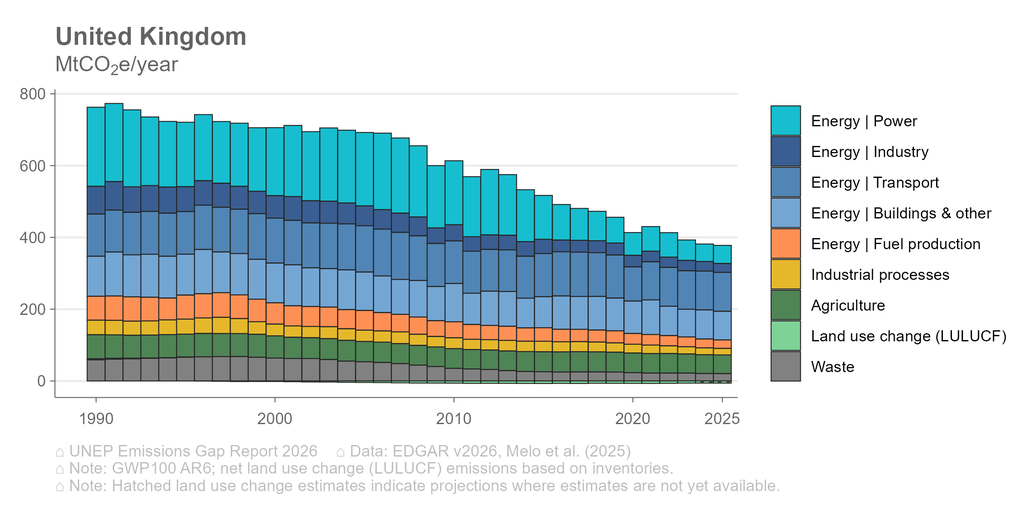

[data](https://github.com/pik-ecs/UNEP-Gap-Report-2026-Chapter-2/raw/main/results/standard/countries/UNEP-EGR-2026-country-trend.xlsx) | png | pdf | svg

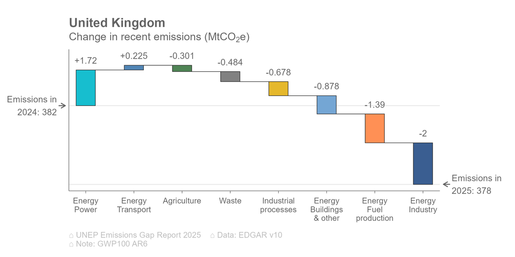

[data](https://github.com/pik-ecs/UNEP-Gap-Report-2026-Chapter-2/raw/main/results/standard/countries/UNEP-EGR-2026-country-change.xlsx) | png | pdf | svg

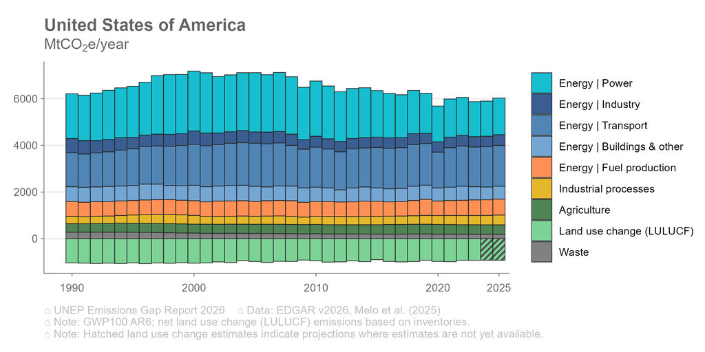

[data](https://github.com/pik-ecs/UNEP-Gap-Report-2026-Chapter-2/raw/main/results/standard/countries/UNEP-EGR-2026-country-trend.xlsx) | png | pdf | svg

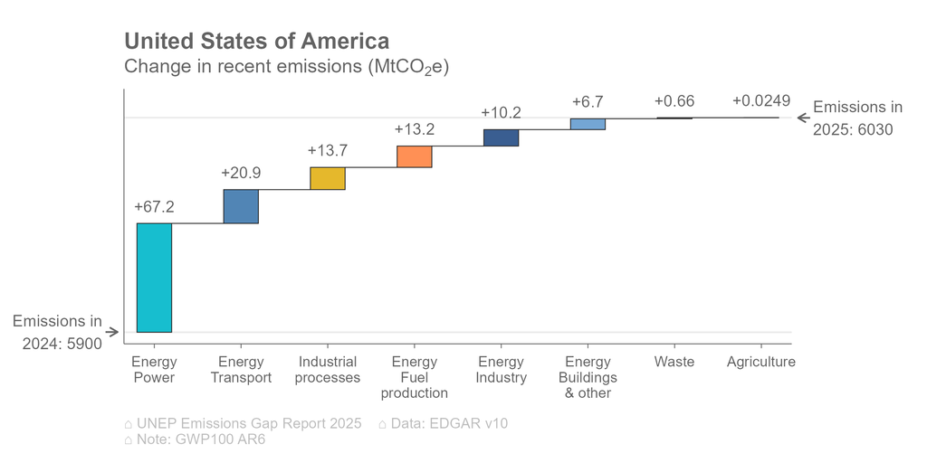

[data](https://github.com/pik-ecs/UNEP-Gap-Report-2026-Chapter-2/raw/main/results/standard/countries/UNEP-EGR-2026-country-change.xlsx) | png | pdf | svg